Name:

# Final Practice 01

1. Solve the linear equation.
   $$20=4(x+3)$$
2. Let function $f$ be defined by the algebraic expression below:
   $$f(x)=\frac{x}{5}+9$$
   Evaluate $f(-15)$.
3. Let function $f$ be defined by the algebraic expression below:
   $$f(x)=\sqrt[5]{x-4}+3$$
   Find the inverse of function $f$.
4. When a relation is displayed as a curve on an $x,y$ plane:
   1. What is needed for $y$ to be a function of $x$?
   2. What is needed for $x$ to be a function of $y$?
   3. What is needed for the curve to represent a one-to-one function?
5. Solve the radical equation:
   $$7-\sqrt{x+10}=4$$
6. Solve the equation.
   $$(8x-3)(5x+6)=0$$
7. State the quadratic formula.
8. Factor the quadratic expression.
   $$x^2-10x+9$$
9. Factor the quadratic expression.
   $$3x^2+x-10$$
10. Expand the quadratic expression. $(x+6)(x+7)$
11. Rationalize the denominator. Remember, $i=\sqrt{-1}$.
    $$\frac{3-2i}{5-9i}$$
12. Expand the quadratic polynomial with complex roots.
    $$(x-(5+2i))(x-(5-2i))$$
13. Solve the quadratic equation.
    $$x^2-6x+13=0$$

The questions on this page refer to this graph.

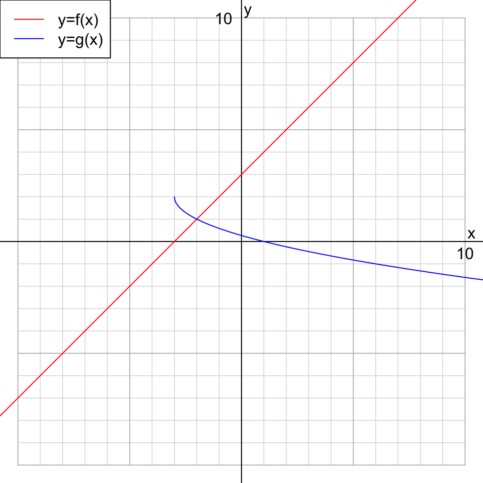

14. Write an equation in slope-intercept form for $f(x)$.
15. Write an equation for $g(x)$.
16. Find the valid solution to $f(x)=g(x)$.
17. Find the extraneous solution to $f(x)=g(x)$.
18. Remember $i=\sqrt{-1}$. Simplify $i^{82}$.
19. Expand the binomial power expression.
    $$(3x+2)^4$$
20. Expand the product.
    $$(x^4+2x+3)(x^3-6)$$
21. Use polynomial division to express as a polynomial plus the remainder over the divisor.
    $$\frac{2x^3-13x^2+22x+2}{x-3}$$
22. If $f(x)$ is a polynomial and $\frac{f(x)}{x-5}=2x^5-3x^3+2x+8$ for all values of $x$ (except $x=5$), then the remainder theorem promises that $f(5)$ equals what and why?
23. What is the $y$ intercept of the polynomial function $y=5x^3-2x^2+3x-8$?
24. Factor the polynomial $x^3-2x^2-11x+12$.
25. Simplify the radical $\sqrt{75}$.
26. A polynomial function is plotted below.

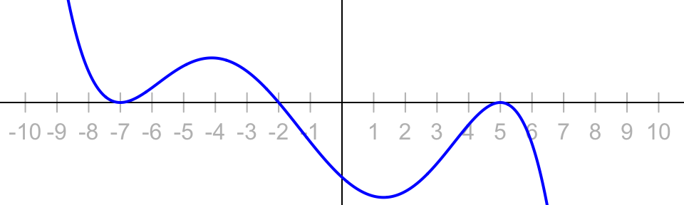

    Express the polynomial in **factored** form. Please assume that in standard form the leading coefficient would be 1 or -1.
27. A polynomial function is plotted below.

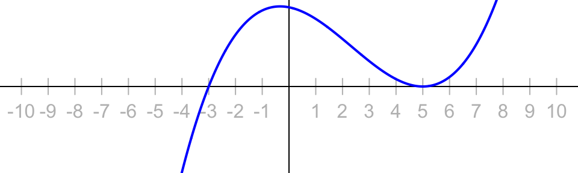

    Express the polynomial in **expanded** form. Please assume that in standard form the leading coefficient would be 1 or -1.
28. A polynomial is plotted below.

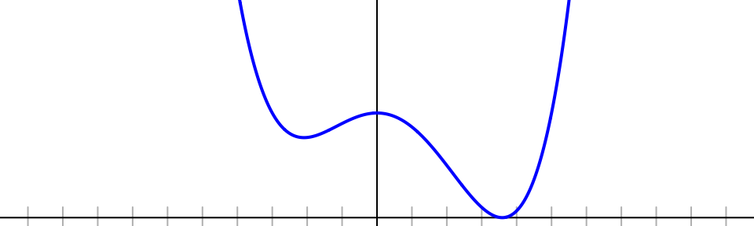

    What is the minimum degree of the polynomial?
29. The discriminant, $b^2-4ac$, is the expression in the radicand in the quadratic formula. Describe the implications of the discriminant being less than 0, more than 0, or equal to 0.
30. Express $\left(x+1\right)^{2}-3\left(x+1\right)-10$ in factored form.
31. Check if $x-2$ is a factor of $x^3-x^2-10x-8$ by using synthetic division.
32. Find solution set to $\sqrt{2x+8}-3=x+1$. Express your answer as a set (listed in curly braces).
33. The graph of $y=p(x)$ below shows a polynomial.

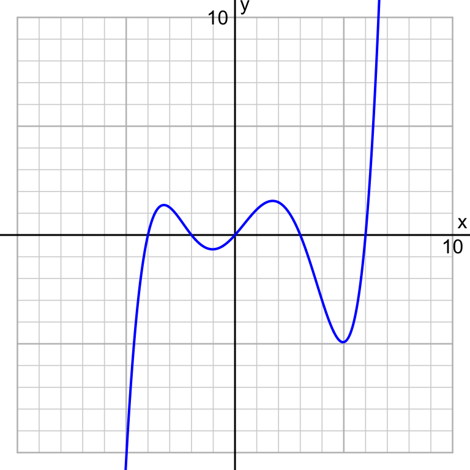

    What is the remainder when $p(x)$ is divided by $x-4$?
34. Consider the function graphed below.

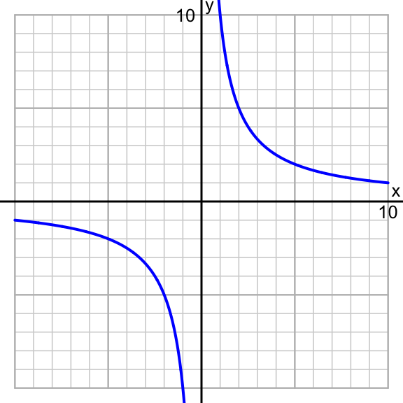

    1. Is the function even?
    2. Is the function odd?
    3. Is the function one-to-one?
35. Consider the function graphed below.

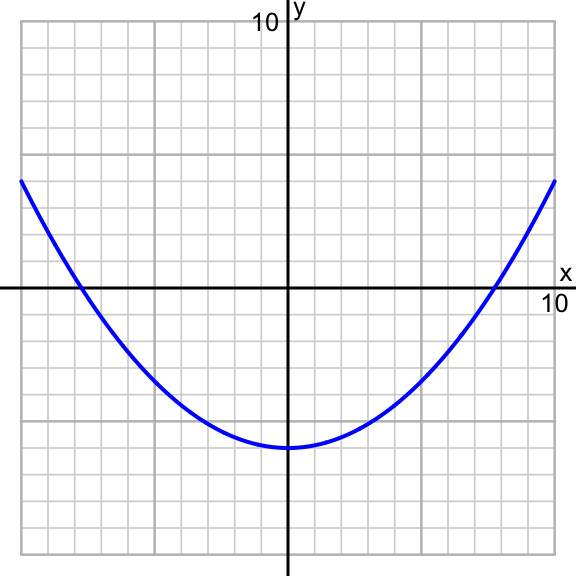

    1. Is the function even?
    2. Is the function odd?
    3. Is the function one-to-one?
36. Consider the function graphed below.

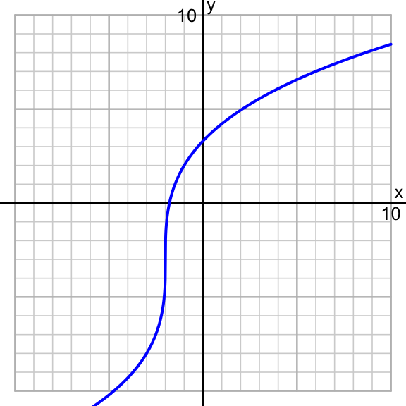

    1. Is the function even?
    2. Is the function odd?
    3. Is the function one-to-one?
37. Find a cubic polynomial with leading coefficient 1 and roots of $2$ and $1+3i$.
38. Find a cubic polynomial with integer coefficients and a positive leading coefficient that is as small as possible and roots of $\frac{2}{3}$ and $\frac{-3}{4}$ and $-2$.
39. Consider the function graphed below. Assume the domain is $x$ values between -10 and 10 (so the entire function is shown here).

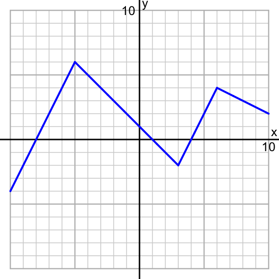

    1. Using interval notation, express where the function is positive.
    2. Using interval notation, express where the function is negative.
    3. Using interval notation, express where the function is increasing.
    4. Using interval notation, express where the function is decreasing.
40. Sketch the polynomial on the axes below. Be accurate with the $x$ intercepts and where the function is positive or negative.
    $$y=(x+3)^2\cdot
    (x-5)\cdot (x+8) \cdot (x-1)$$

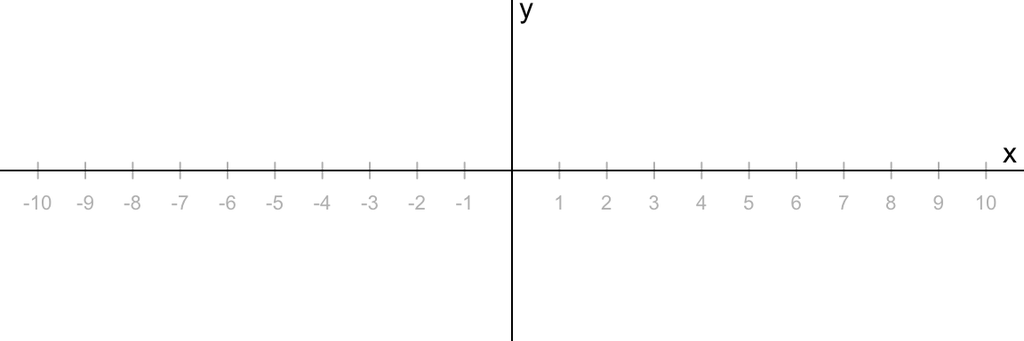

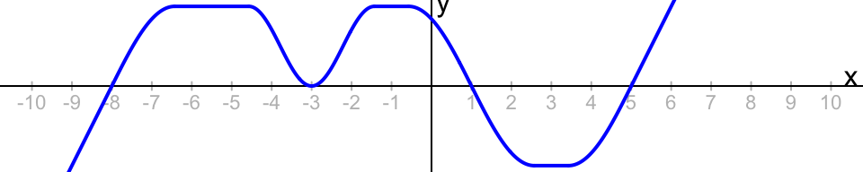